# Stokes 3D sobre una superficie que contiene el campo electrico en todo momento.

Sea $\vec{E}(\vec{r},z)$ un campo cualquiera, se pueden considerar su parte real e imaginaria por separado

\begin{equation} \vec{E}(\vec{r},z) = \vec{A}(\vec{r},z) + i \vec{B}(\vec{r},z) \label{eq:first} \end{equation}

Se puede demostrar que existen dos vectores $\vec{P}(\vec{r},z)$ y $\vec{Q}(\vec{r},z)$ ortogonales entre sí que vienen dados por

\begin{equation} \vec{P}(\vec{r},z) = \cos\left[\alpha(\vec{r},z)\right] \cdot \vec{A}(\vec{r},z) + \sin\left[\alpha(\vec{r},z)\right] \cdot \vec{B}(\vec{r},z) \label{eq:P} \end{equation}\begin{equation} \vec{Q}(\vec{r},z) = \cos\left[\alpha(\vec{r},z)\right] \cdot \vec{B}(\vec{r},z) - \sin\left[\alpha(\vec{r},z)\right] \cdot \vec{A}(\vec{r},z) \label{eq:Q} \end{equation}

donde \begin{equation} \tan\left[2\alpha(\vec{r},z)\right] = \frac{2\, \vec{A}\cdot\vec{B}}{|\vec{A}|^2 - |\vec{B}|^2} \label{eq:alpha} \end{equation}

Entonces $\vec{P}$ i $\vec{Q}$ y $\vec{N}= \vec{P}\times\vec{Q}$ son un conjunto de tres vectores ortogonales en cada punto del haz. El campo puede escrivirse como

\begin{equation} E_P = \frac{\vec{E}\cdot\vec{P}}{|\vec{P}|} = |\vec{P}|\,e^{i\alpha} \label{eq:E_P} \end{equation}\begin{equation} E_Q = \frac{\vec{E}\cdot\vec{Q}}{|\vec{Q}|} = i\,|\vec{Q}|\,e^{i\alpha} \label{eq:E_Q} \end{equation}\begin{equation} E_N = 0 \quad;\quad\forall\,(\vec{r},z) \label{eq:E_N} \end{equation}

Es decir, el campo está contenido en el plano $PQ$ y $\vec{N}$ es la normal a dicho plano. Entonces, el campo será, por lo general, elipticamente polarizado referido a los ejes $\vec{P}$ i $\vec{Q}$. Notese que $\vec{A} \times \vec{B} = \vec{P} \times \vec{Q}$

Se puede demostrar que los parametros de Stokes del campo $\vec{E}$ en cada punto, y referidos a dicho plano $PQ$ pueden calcularse como \begin{equation} S_0(\vec{r},z) = |\vec{E}(\vec{r},z)|^2 = |\vec{A}(\vec{r},z)|^2 + |\vec{B}(\vec{r},z)|^2 \label{eq:S0} \end{equation} \begin{equation} S_1(\vec{r},z) = \frac{|\vec{A}(\vec{r},z)|^2 - |\vec{B}(\vec{r},z)|^2}{\cos\left[2\,\alpha(\vec{r},z)\right]} \label{eq:S1} \end{equation} \begin{equation} S_2(\vec{r},z) = 0 \label{eq:S2} \end{equation} \begin{equation} S_3(\vec{r},z) = 2\, \left| \vec{A}(\vec{r},z)\times\vec{B}(\vec{r},z) \right| \label{eq:S3} \end{equation}

### 1. Campo incidente circularmente polarizado

Se ensaya con el siguiente campo incidente circularmente polarizado a derechas

\begin{equation} \vec{E}^{circ}_S(\theta, \varphi) = \frac{1}{\sqrt{2}} g_{_C}(\theta) \left(1,i\right) \label{eq:E0_dextro} \end{equation}

donde

\begin{equation} g_{_C}(\theta) = \frac{ \exp\left\{ -\frac{ \sigma\left( \cos\theta - \bar{\alpha} \right) }{ 2\,(1-\alpha_0)^2 } \right\} }{ \pi\sqrt{\cos\theta}\left(1+\cos\theta\right) } \label{eq:g} \end{equation}

Se estima el campo en el plano focal gracias al método de 'phase retrieval' [cita al SciRep].

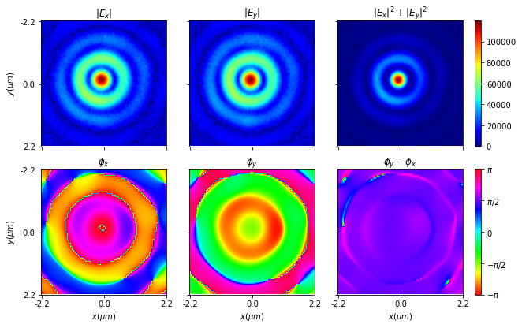

```
Figure 1: (Pol. Circular) Campo transversal en el plano focal, medido experimanetalmente
```

A continuación, estimamos el campo longitudinal en el plano focal calculado a través de [cita al SciRep]

\begin{equation} E_z(\vec{k}_\perp; z=0) = \mathcal{F^{-1}}\left[ - \frac{\vec{k}_\perp \cdot \mathcal{F}\left\{\vec{E}_\perp(\vec{k}_\perp; z=0)\right\}}{k_z} \right] \label{eq:Ez} \end{equation}

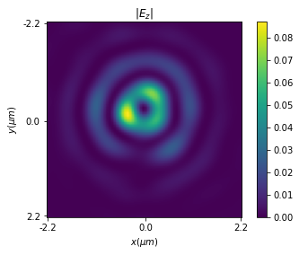

```
Figure 2: (Pol. Circular) Amplitud de la componente longitudinal en el plano focal.
```

Calculamos los parametros de Stokes según las ecuacones de \eqref{eq:S0} a \eqref{eq:S3} y mostramos los resultados en la siguiente figura

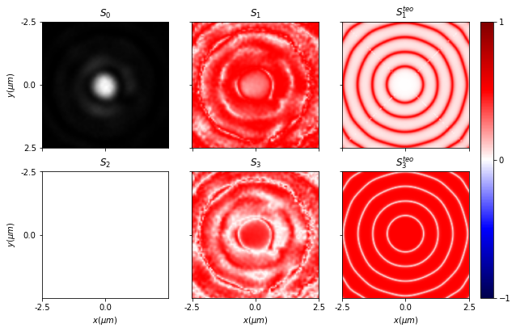

```
Figure 3: (Pol. Circular) Stokes 3D en la base PQ y comparativa con el resultado numérico
```

### 2. Campo incidente radialmente polarizado (sin singularidad central)

\begin{equation} \vec{E}_S^{rad}(\theta, \varphi) = \frac{1}{\sqrt{2}} g_{_R}(\theta) \left( \cos\varphi, \sin\varphi \right) \label{eq:E0_radial} \end{equation}

donde $g_{_R}(\theta) = g_{_C}(\theta)\sin(\theta)$, para evitar la singularidad.

A continuación mostramos el campo transversal en el plano focal para el caso de campo incidente radialmente polarizado

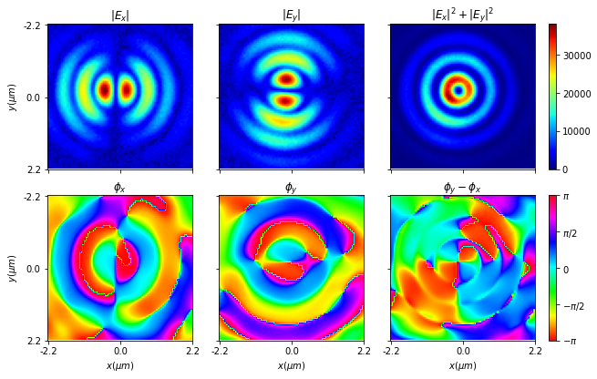

```
Figure 4: (Pol. Radial) Campo transversal en el plano focal, medido experimanetalmente
```

Se calcula la componente longitudinal del campo en el plano focal segun \eqref{eq:Ez}

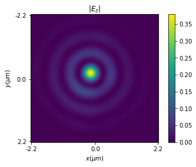

```
Figure 5: (Pol. Radial) Amplitud de la componente longitudinal en el plano focal.
```

Calculamos los parametros de Stokes según las ecuacones de \eqref{eq:S0} a \eqref{eq:S3} y mostramos los resultados en la siguiente figura

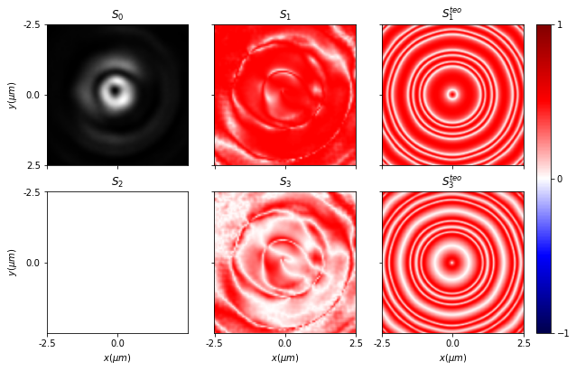

```
Figure 6: (Pol. Radial) Stokes 3D en la base PQ y comparativa con el resultado numérico
```